# Titanic数据探索项目

## 背景介绍：

泰坦尼克号是一艘英国皇家邮轮，也是白星航运公司旗下的3艘奥林匹克级邮轮之一，在其服役时间是全世界最大的海上船舶。 1912年4月10日，泰坦尼克号展开首航，也是唯一一次的载客出航，最终目的地为纽约。当时世界上最富有的一些人都是船上乘客，以及许多来自英国、爱尔兰、斯堪地那维亚和整个欧洲其他地区的移民，他们寻求在美国展开新生活的机会。 4月14至15日子夜前后，在中途发生碰撞冰山后沉没的严重灾难。 2,224名船上人员中有1,514人罹难，成为近代史上最严重的和平时期船难。船长爱德华·约翰·史密斯最终与船一起沉没；泰坦尼克号总设计师汤玛斯·安德鲁斯也在这起灾难中死亡。

## 数据来源

数据集来自 Kaggle 网站，包括泰坦尼克号上 2224 名乘客和船员中 891 名的人口学数据和乘客基本信息。本次研究将主要针对生还率展开，围绕甲板位置，乘客年龄，乘客富有程度（采用客运费作为评价指标）以及乘客性别与生还率之间的联系进行。

## 提出问题

- 问题1：乘客的性别与生还率有怎样的关系？
- 问题2：乘客的年龄与生还率有怎样的关系？
- 问题3：乘客所在的甲板位置与生还率有怎样的关系？
- 问题4：乘客的客运费水平与生还率有怎样的关系？
- 问题5：在同一块甲板上的乘客中，生还率与乘客的客运费水平，有怎样的关系？

## 探索阶段

第一步，以合适的格式导入数据，保留研究需要的6个列，并观察数据的总数/空值等情况

```python
import numpy as np
import pandas as pd
import seaborn as sns
titanic_df = pd.read_csv('titanic-data.csv', header = 0,
                           dtype = {'PassengerId': int,'Survived': int,'Pclass':int,'Name':str,
                                    'Sex':str, 'Age':float, 'SibSp':int, 'Parch':int, 'Ticket':str,
                                    'Fare':float, 'Cabin':str, 'Embarded':str}, engine = 'c')
```

第二步，观察数据，选择的研究指标为 Sex, Age, Cabin, Fare

```python
titanic_df.info()
```

```
<class 'pandas.core.frame.DataFrame'>
RangeIndex: 891 entries, 0 to 890
Data columns (total 12 columns):
PassengerId    891 non-null int32
Survived       891 non-null int32
Pclass         891 non-null int32
Name           891 non-null object
Sex            891 non-null object
Age            714 non-null float64
SibSp          891 non-null int32
Parch          891 non-null int32
Ticket         891 non-null object
Fare           891 non-null float64
Cabin          204 non-null object
Embarked       889 non-null object
dtypes: float64(2), int32(5), object(5)
memory usage: 66.2+ KB
```

第三步，整理数据，去掉空值行，以及无意义的数据行，详情如下：

```
- 删除掉缺失信息的数据行，保留剩余的数据命名为 xxx_df
- 增加年龄分类标签，标签值添加为新的列
- 转化甲板数据为第一位字母(A-F)
- 对客运费进行标准化运算，标准化值添加为新的列
- 对客运费水平按标准化后的比例分类，分类值添加为新的列
```

```python
#删除掉缺失了年龄信息的数据行，保留剩余的数据命名为 age_df
age_df = titanic_df.drop(titanic_df[titanic_df['Age'].isna()].index, inplace=False)
```

```python
#增加年龄分类标签
def group_age(df):
    age_cat=[]
    col_age=df.Age
    for x in col_age:
        if(x<1):
            age_cat.append('infant')
        elif(x<13):
            age_cat.append('child')
        elif(x<19):
            age_cat.append('teenager')
        elif(x<56):
            age_cat.append('adult')
        else:
            age_cat.append('the aged')
    return df.assign(Age_Cat = age_cat)

age_df = group_age(age_df)
```

```python
# 研究不同甲板上的乘客分布，清理甲板信息缺失的数据行
cabin_df = titanic_df.drop(titanic_df[titanic_df['Cabin'].isna()].index, inplace=False)
```

```python
# 研究客运费水平，清理客运费信息缺失的数据行
fare_df = titanic_df.drop(titanic_df[titanic_df['Fare'].isna()].index, inplace=False)
```

```python
# 为了研究同一块甲板的乘客之中，性别，年龄，客运费水平与生还率的关系，
# 删除掉缺失年龄信息，甲板信息，票价信息的数据行，保留剩余的数据命名为 acf_df
acf_df = titanic_df.drop(titanic_df[titanic_df['Age'].isna() | titanic_df['Cabin'].isna() | titanic_df['Fare'].isna()].index, inplace=False)
acf_df = group_age(acf_df)
```

```python
# 为了便于分类甲板信息，将甲板数据的字符只保留第一位
cap_cabin = acf_df.Cabin.astype(str).str[0]
new_cabin = cap_cabin.astype(str).str[0]

# 将甲板数据集与综合数据集的“甲板”列值都更新为第一为字母
cabin_df.update(new_cabin)
acf_df.update(new_cabin)
```

```python
# 标准化客运费水平，增加为新的列，并增加客运费水平分类标签
def nor_group_fare(df, fare_col_name):
    fare = df[fare_col_name]
    fare_n = (fare-fare.mean())/fare.std()
    df = df.assign(Fare_N = fare_n)
    acf_cat=[]
    col_fare_n=df.Fare_N
    for x in col_fare_n:
        if(x<1):
            acf_cat.append('0_1')
        elif(x<2):
            acf_cat.append('1_2')
        elif(x<3):
            acf_cat.append('2_3')
        elif(x<4):
            acf_cat.append('3_4')
        else:
            acf_cat.append('>4')
    return df.assign(Fare_Cat = acf_cat)

acf_cat_df=nor_group_fare(acf_df,'Fare')
nor_fare_df = nor_group_fare(fare_df,'Fare')
```

```python
# 将所需数据集的无用列去掉：
gender = titanic_df.filter(['Survived','Sex'], axis=1)
age = age_df.filter(['Survived','Age_Cat'], axis=1)
fare = nor_fare_df.filter(['Survived','Fare_Cat'], axis=1)
cabin = cabin_df.filter(['Survived','Cabin'], axis=1)
acf = acf_cat_df.filter(['Survived','Sex','Age_Cat','Fare_Cat','Cabin'], axis=1)
```

数据集整理完毕，定义一个基本统计函数来查看整理好的研究指标的基本统计数据：

```python
def describe_data(data):
    data_ls = list(data)
    print ('Mean:', np.mean(data_ls))
    print ('Standard deviation:', np.std(data_ls))
    print ('Minimum:', np.min(data_ls))
    print ('Maximum:', np.max(data_ls))
```

接下来，分别查看整理好的指标：

```python
describe_data(age_df.Age)
```

```
Mean: 29.69911764705882
Standard deviation: 14.516321150817316
Minimum: 0.42
Maximum: 80.0
```

```python
describe_data(nor_fare_df.Fare_N)
```

```
Mean: 7.237009345704724e-16
Standard deviation: 0.999438675229417
Minimum: -0.6480576784030059
Maximum: 9.661740104981662
```

由于性别，所在甲板，这些属于分类特征，不是数字，无法直接展开数理统计，所以我们转而这些分类特征对应的乘客数量：

```python
def count_passenger(df, key):
    key_list = df[key].unique()
    new_df = pd.DataFrame({key: key_list})
    col_indexer = 'Passenger Count'
    for x in df[key]:
        row_indexer = new_df.index[new_df[key]==x]
        new_df.loc[row_indexer,col_indexer]=len(df[df[key] == x])
    return new_df
```

```python
count_passenger(titanic_df,'Sex')
```

|  | Sex | Passenger Count |
| --- | --- | --- |
| 0 | male | 577.0 |
| 1 | female | 314.0 |

用饼图表现总乘客数量中男女的百分比:

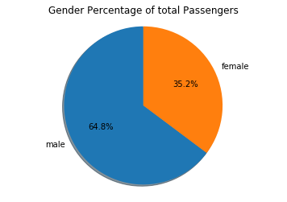

```python
import matplotlib.pyplot as plt
labels = count_passenger(gender,'Sex').Sex
sizes = count_passenger(gender,'Sex')['Passenger Count']

fig1, ax1 = plt.subplots()
ax1.pie(sizes, labels=labels, autopct='%1.1f%%', shadow=True, startangle=90)
ax1.axis('equal')
ax1.set_title('Gender Percentage of total Passengers')
plt.show()
```

同样地，观察不同年龄段的登船乘客数量，并用饼图来展现各种年龄乘客所占的百分比

```python
count_passenger(age_cat_df,'Age_Cat')
```

[output not shown]

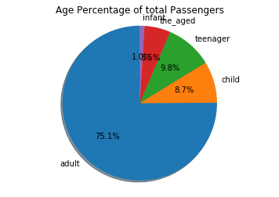

```python
labels = count_passenger(age_cat_df,'Age_Cat').Age_Cat
sizes = count_passenger(age_cat_df,'Age_Cat')['Passenger Count']

fig1, ax1 = plt.subplots()
ax1.pie(sizes, labels=labels, autopct='%1.1f%%', shadow=True, startangle=90)
ax1.axis('equal')
ax1.set_title('Age Percentage of total Passengers')
plt.show()
```

```python
cabin = cabin_df.drop(cabin_df[~cabin_df.Cabin.isin({'A','B','C','D','E','F','G'})].index, inplace=False)
```

处理好甲板数据之后，继续观察比较不同甲板上的乘客数量，并用饼图来观察百分比

```python
count_passenger(cabin,'Cabin')
```

|  | Cabin | Passenger Count |
| --- | --- | --- |
| 0 | C | 51.0 |
| 1 | E | 30.0 |
| 2 | G | 4.0 |
| 3 | D | 31.0 |
| 4 | A | 12.0 |
| 5 | B | 45.0 |
| 6 | F | 11.0 |

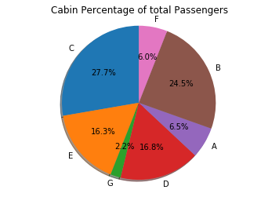

```python
labels = count_passenger(cabin,'Cabin').Cabin
sizes = count_passenger(cabin,'Cabin')['Passenger Count']

fig1, ax1 = plt.subplots()
ax1.pie(sizes, labels=labels, autopct='%1.1f%%', shadow=True, startangle=90)
ax1.axis('equal')

ax1.set_title('Cabin Percentage of total Passengers')
plt.show()
```

观察比较不同客运费水平对应的乘客数量，并用饼图来观察百分比

```python
count_passenger(nor_fare_df,'Fare_Cat')
```

|  | Fare_Cat | Passenger Count |
| --- | --- | --- |
| 0 | 0_1 | 818.0 |
| 1 | >4 | 11.0 |
| 2 | 2_3 | 18.0 |
| 3 | 1_2 | 35.0 |
| 4 | 3_4 | 9.0 |

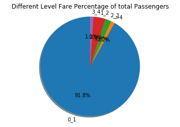

```python
labels = count_passenger(nor_fare_df,'Fare_Cat').Fare_Cat
sizes = count_passenger(nor_fare_df,'Fare_Cat')['Passenger Count']

fig1, ax1 = plt.subplots()
ax1.pie(sizes, labels=labels, autopct='%1.1f%%', shadow=True, startangle=90)
ax1.axis('equal')
ax1.set_title('Different Level Fare Percentage of total Passengers')
plt.show()
```

## 第四步 展开分析

首先定义生还率的计算函数，为每一组数据计算生还率

```python
def create_df(df, key):
    key_list = df[key].unique()
    new_df = pd.DataFrame({'key': key_list})
    #df_pct = group_data(df, key)
    col_indexer = 'Percent'
    for x in key_list:
        row_indexer = new_df.index[new_df['key']==x]
        #new_df.loc[row_indexer,col_indexer]=df_pct.get(x)
        new_df.loc[row_indexer,col_indexer]=len(df[(df[key]==x) & (df['Survived']==1)])/len(df[df[key]==x])
    return new_df
```

首先比较不同男性与女性的生还率，男性约为20%，女性约为70%，女性生还率大大高于男性生还率

```python
p_gender=create_df(gender,'Sex')
p_gender
```

|  | key | Percent |
| --- | --- | --- |
| 0 | male | 0.188908 |
| 1 | female | 0.742038 |

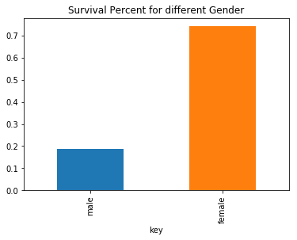

```python
p_gender.plot(x='key',y='Percent',kind='bar',title='Survival Percent for different Gender',legend=False)
```

然后比较不同年龄段乘客生还率，可见婴儿生还率最高，为100%，其次为儿童，而老年人生还率最低

```python
p_age=create_df(age,'Age_Cat')
p_age
```

|  | key | Percent |
| --- | --- | --- |
| 0 | adult | 0.388060 |
| 1 | child | 0.532258 |
| 2 | teenager | 0.428571 |
| 3 | the aged | 0.307692 |
| 4 | infant | 1.000000 |

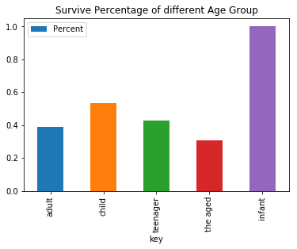

```python
p_age.plot(x='key',y='Percent',kind='bar',title='Survive Percentage of different Age Group')
```

接下来比较不同甲板上乘客的生还率，最高的为甲板B (75.56%)，最低的是甲板G (50%)

```python
p_cabin=create_df(cabin,'Cabin')
p_cabin
```

|  | key | Percent |
| --- | --- | --- |
| 0 | C | 0.588235 |
| 1 | E | 0.733333 |
| 2 | G | 0.500000 |
| 3 | D | 0.741935 |
| 4 | A | 0.583333 |
| 5 | B | 0.755556 |
| 6 | F | 0.636364 |

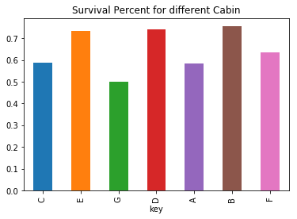

```python
p_cabin.plot(x='key',y='Percent',kind='bar',title='Survival Percent for different Cabin',legend=False)
```

接下来比较不同客运费水平对应的乘客生还率，最高的为标准化客运费值在1-2之间的乘客 (80%)，最低的是0-1之间 (34.96%)

```python
p_fare=create_df(fare,'Fare_Cat')
p_fare
```

|  | key | Percent |
| --- | --- | --- |
| 0 | 0_1 | 0.349633 |
| 1 | >4 | 0.727273 |
| 2 | 2_3 | 0.777778 |
| 3 | 1_2 | 0.800000 |
| 4 | 3_4 | 0.666667 |

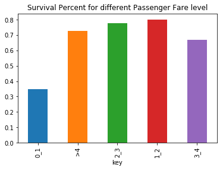

```python
p_fare.plot(x='key',y='Percent',kind='bar',title='Survival Percent for different Passenger Fare level',legend=False)
```

由之前的探索，发现甲板B的生还率高过其他甲板。那么同在B甲板上，乘客的年龄，客运费于生还情况如何呢？

首先单独提取甲板B上的乘客信息数据

```python
cabin_b_df=acf.drop(acf[acf.Cabin!='B'].index, inplace=False)
```

观察B甲板上客运费水平与生还率的关系。生还率最高的为客运费水平1-2之间以及>4的乘客(100%)，其他另种客运费水平的乘客生还率稍低(72.22%, 75%)

```python
p_fare_in_cab=create_df(cabin_b_df,'Fare_Cat')
p_fare_in_cab
```

|  | key | Percent |
| --- | --- | --- |
| 0 | 0_1 | 0.722222 |
| 1 | 2_3 | 0.750000 |
| 2 | >4 | 1.000000 |
| 3 | 1_2 | 1.000000 |

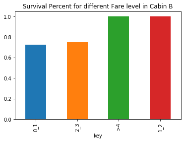

```python
p_fare_in_cab.plot(x='key',y='Percent',kind='bar',title='Survival Percent for different Fare level in Cabin B',legend=False)
```

观察B甲板上乘客年龄与生还率的关系。生还率最高的为孩童(100%)与青少年(100%)，其次为成年人(77.42%)，最低为老年人(42.86%)

```python
p_age_in_cab=create_df(cabin_b_df,'Age_Cat')
p_age_in_cab
```

|  | key | Percent |
| --- | --- | --- |
| 0 | the aged | 0.428571 |
| 1 | adult | 0.774194 |
| 2 | teenager | 1.000000 |
| 3 | child | 1.000000 |

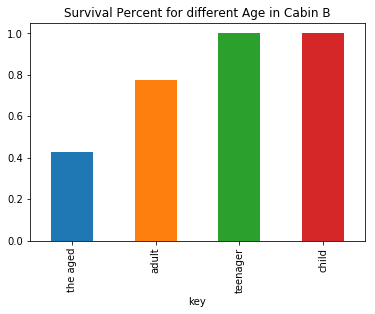

```python
p_age_in_cab.plot(x='key',y='Percent',kind='bar',title='Survival Percent for different Age in Cabin B',legend=False)
```

观察B甲板上乘客性别与生还率的关系。女性生还率为100%， 高于男性生还率42.1%。

```python
p_gender_in_cab=create_df(cabin_b_df,'Sex')
p_gender_in_cab
```

|  | key | Percent |
| --- | --- | --- |
| 0 | male | 0.421053 |
| 1 | female | 1.000000 |

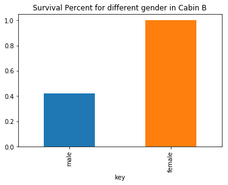

```python
p_gender_in_cab.plot(x='key',y='Percent',kind='bar',title='Survival Percent for different gender in Cabin B',legend=False)
```

基于以上观察，我们可以初步确定年幼者，女性，在逃生过程中是受到了照顾的。但同时，0_1客运费水平的乘客的生还率表现(72.22%)，与之前观察到的基于总体乘客的生还率(34.96%)表现有较大差异。  
我们怀疑这种差异是由性别差异或年龄引起（例如，0_1组包含了多数女性，或者多数幼者,他们受到了照顾，提高了小组的生还率）。由此展开进一步观察，对于同样的甲板，我们进行不同客运费水平分组的组间对比，以及0_1组的特别分析:

将B甲板上的乘客信息按客运费水平分组并直接打印，可以发现：

- 0_1组包含16位男性乘客，20名女性，女性均生还，男性生还6人（其中4位成人，1位老年人，1位孩童）
- 1_2组包含3名女性乘客，均生还
- 2_3组包含1名男性，3名女性，女性均生还，男乘客遇难
- '>4组包含2名男性，均生还

```python
gb_cabin_b_df=cabin_b_df.groupby('Fare_Cat')
gb = gb_cabin_b_df.groups

for key, item in gb_cabin_b_df:
    print(gb_cabin_b_df.get_group(key), "\n\n")
```

```
     Survived     Sex   Age_Cat Fare_Cat Cabin
54          0    male  the aged      0_1     B
61          1  female     adult      0_1     B
139         0    male     adult      0_1     B
170         0    male  the aged      0_1     B
194         1  female     adult      0_1     B
195         1  female  the aged      0_1     B
257         1  female     adult      0_1     B
263         0    male     adult      0_1     B
291         1  female     adult      0_1     B
329         1  female  teenager      0_1     B
369         1  female     adult      0_1     B
390         1    male     adult      0_1     B
435         1  female  teenager      0_1     B
484         1    male     adult      0_1     B
```

[output cut: 40 more lines]

这样的结果部分符合我们之前的猜测：

由对于0_1组的特别观察，性别的比例以及男性幼者受到的照顾影响了小组内部的生还率，显得高于全船乘客中客运费水平在0_1之间的生还率。

由组间对比，B甲板上的底层及中层的男性们的行为仍然是照顾把逃生机会让给幼童及女性，而最富有的阶层中的男性们选择了求生并且获得了成功。

以上观察的结果，由于受到样本量的局限，不适合用作代表全船整体的结论，只能够代表甲板B内部的情况。

## 得出结论

- 由单个变量分析观察的结果，我们发现女性的生还率高于男性，婴孩与青少年的生还率高于成年人及老年人，不同的甲板上的乘客生还率差距较大（BDE明显高于 ACFG）,客运费水平的乘客群体的生还率明显低于较高客运费水平的乘客。
- 由多维变量分析角度，单独取甲板B上的乘客群体观察，依旧是女性生还率高于男性，婴孩与青少年的生还率高于成年人及老年人，而客运费最低的乘客生还率低于客运费最高的乘客。

### 由以上发现，我们可以推测：

- 在灾难降临时，女性，婴儿，孩童得到了更多的照顾，获得了更多求生的机会
- 不同位置甲板的特性差别（例如沉没时间先后，与救生艇相隔的距离）导致了生还率的差异
- 从贫富角度来看，处于最底层的乘客的生还情况整体弱于中层与上层阶级的乘客
- 面对道德抉择（先让其他弱势群体逃生），小部分富有阶级得乘客会优先选择自己逃生

### 局限性：

- 分组机制：单纯按客运费高低划分乘客的贫富程度，有一定的风险导致误差，例如没有考虑乘客旅程长短对于票价得影响。（但是，由于定价机制未知，且三港均在欧洲，尚未跨洋，所以我们可以假设不同港口上船的票价相差不会太多，故不再根据上船港口调整划分客运费水平。）
- 变量间影响：对于每个单变量分析的前提假设了它与其他各变量独立，但是事实上未必如此。例如我们在观察年龄与生还率的关系时，假设全船乘客的其他各种因素（性别，贫富水平，所处甲板）因素均没有影响，但是事实上是有影响的，而且还有更多的潜在因素没有被选入本次研究的观察范围。
- 样本量：在最后的基于B甲板的生还率观察，贫富-性别观察，贫富-年龄观察中，样本量只有数十人，所以最后的关于贫富阶级的不同选择的推测，也只对于B甲板内部情况有代表性。

# 参考链接

数据来源：  
https://www.kaggle.com/c/titanic/data

Pandas Dataframe操作：  
https://stackoverflow.com/questions/13851535/how-to-delete-rows-from-a-pandas-dataframe-based-on-a-conditional-expression  
https://stackoverflow.com/questions/35552874/get-first-letter-of-a-string-from-column  
https://stackoverflow.com/questions/21608228/conditional-replace-pandas/21608417  
https://pandas.pydata.org/pandas-docs/stable/generated/pandas.DataFrame.update.html  
https://stackoverflow.com/questions/21800169/python-pandas-get-index-of-rows-which-column-matches-certain-value  
https://stackoverflow.com/questions/19960077/how-to-implement-in-and-not-in-for-pandas-dataframe  
https://stackoverflow.com/questions/22691010/how-to-print-a-groupby-object

视图选择及调整：  
https://matplotlib.org/api/pyplot_api.html  
https://matplotlib.org/examples/pie_and_polar_charts/pie_demo_features.html  
https://matplotlib.org/api/_as_gen/matplotlib.pyplot.bar.html  
https://matplotlib.org/api/_as_gen/matplotlib.pyplot.title.html

泰坦尼克号资料：  
https://zh.wikipedia.org/wiki/%E6%B3%B0%E5%9D%A6%E5%B0%BC%E5%85%8B%E5%8F%B7  
https://translate.google.com.hk/?hl=zh-TW

Markdown格式调整：  
https://github.com/adam-p/markdown-here/wiki/Markdown-Cheatsheet  
https://gist.github.com/shaunlebron/746476e6e7a4d698b373